# Shopping Dataset for Marketing Purposes

### Discount Usage by Payment Method

[figure not shown]

Figure 8

### Proportion of Total Transactions by Payment Method

| Payment Method | Proportion of Transactions |
| --- | --- |
| PayPal | 0.174 |
| Credit Card | 0.172 |
| Cash | 0.172 |
| Debit Card | 0.163 |
| Venmo | 0.163 |
| Bank Transfer | 0.157 |

Figure 9: Proportion of Total Transactions by Payment Method

#### Insights on Discount Usage by Payment Method and the Proportion of Total Transactions by Payment Method

Figure 8 reveals remarkably consistent discount usage patterns across all payment methods, with approximately 60% of transactions not receiving discounts (red) and 40% receiving discounts (green) regardless of how customers pay. The uniformity across Bank Transfer, Cash, Credit Card, Debit Card, PayPal, and Venmo suggests that discount application is independent of payment method choice in this dataset. Debit Card are more price-sensitive, since they used a higher proportion of discounts (45%). Even though it is clear that it was a slight difference it stands out compared to the rest of the data. We also see that payment method promotions are unlikely to drive results. Discount usage is shown as slightly uniform across payment types and payment method doesnt seem to vary. In Figure 9, we can see that the proportion of different payment usage doesnt necessarily vary. In addition, since 60% of customers purchase without discounts, there’s room for growth by offering discounts based on purchase frequency since customers would purchase more tend to spend more.

### Revenue Across Age Groups by Subscription Status

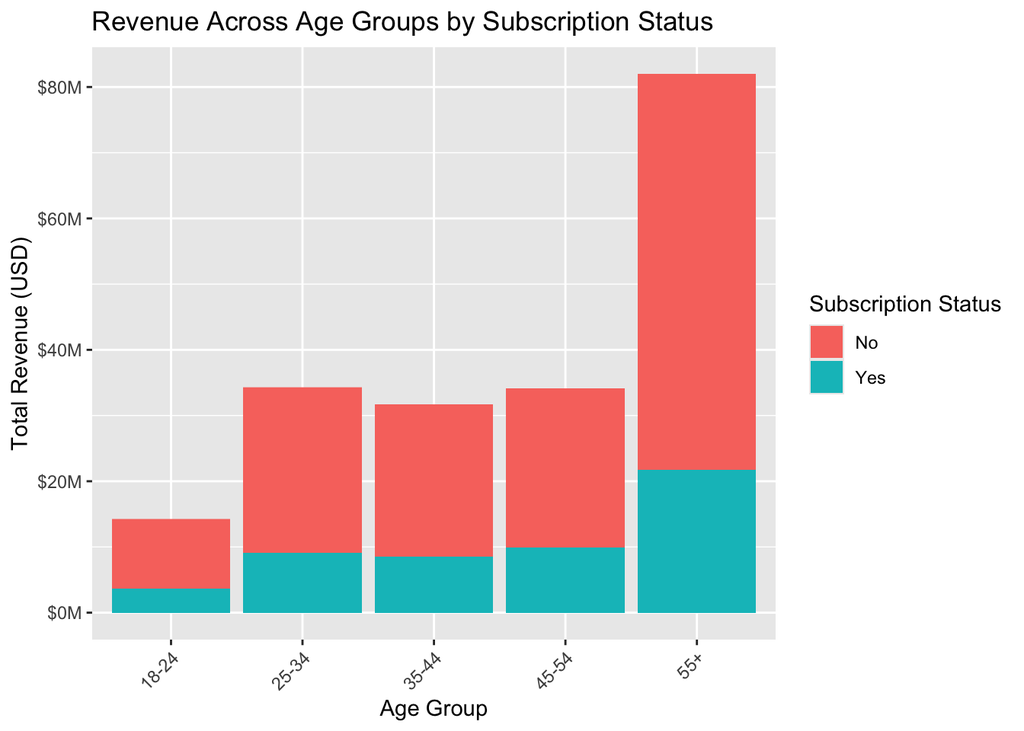

Figure 10